# Gam models: summary

# Research question

How did neonatal health evolve through time in Switzerland (2007-2020) ? Particularly, did it change during two important crisis: the 2008-2009 economic crisis and the current COVID-19 pandemic ?

We focus on the evolution of birthweight and gestational age, and on the rates of stillbirth, preterm birth, lowbirth weight and macrosomia babies.

## Background on COVID-19:

- COVID-19 infection among pregnant women : higher risk of severe symptoms (Kotlar et al., 2021; Villar et al., 2021).
- Babies born from COVID+ mothers: increased rate of preterm births (Kotlar et al., 2021; McClymont et al., 2022; Villar et al., 2021).
- pregnant women with comorbidities : higher risk of severe COVID-19, and important rates of stillborn and preterm neonates; ++ risk if infection during the third trimester (Vousden, 2022, UK study).
- In Switzerland: maternal SARS-CoV-2 infection associated with increased incidence of low placental weight (Radan et al., 2022).
- mental health among women worsened during COVID-19 : depression, stress and anxiety observed (Kotlar et al., 2021).
- In Switzerland: increase in the rate of pregnant and breastfeeding women with depression and severe-anxiety-like symptoms (Lambelet et al., 2021, cross-sectionnal study).

# Data and Methods

## Data

We used data from the Federal Office of Statistics: Bevnat. It covers:

- All births that occurred in Switzerland
- Between 1987 and 2020 (year 2021 will soon be included)
- Temporal level: monthly
- Spatial level: Gemeinde nummer (municipality)

## Variables

### Socio economic and spatial variables

- Swiss-SEP Average Swiss neighbourhood index of socioeconomic position (Swiss-SEP 2.0). Swiss-SEP 2.0 indicates the average socioeconomic situation in a municipality. It was developed by the Institute for Social and Preventive Medicine at the University of Bern.
- Language region: German (+Romansh), French, Italian
- Urbanicity of the place : Urban versus Rural
- Grossregion, canton, districts
- Gemeinde nummer/municipality

## Exclusions steps

- As gestational age was only recorded systematically from 2007, we analysed data from this year only
- Steps of exclusions: see the ppt

Definitions:

- Preterm birth babies : <37 weeks
- Low birthweight babies : <2500g
- Macrosomia babies: >= 4000g
- “normal” birthweight babies: >2500 and <4000

We work with two different datasets:

- one that includes stillbirth cases to investigate stillbirth outcome: bevn_eco_in6.
- one that excludes stillbirth cases to investigate birthweight/gestational age/ preterm birth/ low birth weight/ macrosomia outcomes : bevn_eco_in7.

## Characteristics at inclusion and in two other datasets used

- see tables in html (folder: output/tables)

## Methods

We built different GAM models, investigating the following outcomes:

- birthweight as a continuous variable
- stillbirth : binary yes/no variable
- (gestational age: as a continuous variable, in days)
- preterm birth: binary yes/no variable.
- (low birthweight: binary yes/no variable, comparing LBW babies vs the rest)
- low birthweight: binary yes/no variable, comparing LBW babies vs “normal” birthweight babies
- macrosomia: binary yes/no variable, comparing macrosomia babies vs “normal” birthweight babies

In the models the variable “birth_Y_M_num” is used to account for time: it is numerical monthly time, with 1= January 2007 and 168=December 2020.

# Birthweight

## 2007-2020

```
##
## Family: gaussian
## Link function: identity
##
## Formula:
## BW ~ s(GA_weeks) + s(mat_age) + s(birth_Y_M_num) + s(month, bs = "cc") +
##     s(mean_ssep2) + parity_cat + sex + Urban3 + Language + mother_nationality_cat2
##
## Parametric coefficients:
##                                                       Estimate Std. Error  t value Pr(>|t|)
## (Intercept)                                          3331.7066     0.8355 3987.630  < 2e-16 ***
## parity_cat(1,2]                                       127.4804     0.8349  152.681  < 2e-16 ***
## parity_cat(2,3]                                       173.6460     1.2779  135.887  < 2e-16 ***
## parity_cat(3,20]                                      199.7985     2.2156   90.178  < 2e-16 ***
## sex2                                                 -147.0356     0.7462 -197.045  < 2e-16 ***
## Urban3                                                  0.6605     0.7910    0.835    0.404
## LanguageFrench                                        -48.1330     0.9187  -52.391  < 2e-16 ***
## LanguageItalian                                       -63.1428     2.0500  -30.801  < 2e-16 ***
## mother_nationality_cat2Africa                          11.0284     2.2736    4.851 1.23e-06 ***
## mother_nationality_cat2Asia                           -17.9278     2.0596   -8.704  < 2e-16 ***
## mother_nationality_cat2Europe                          32.5720     0.8501   38.313  < 2e-16 ***
## mother_nationality_cat2Northern America                65.0200     4.8547   13.393  < 2e-16 ***
## mother_nationality_cat2Southern and Central America    47.0244     2.7992   16.799  < 2e-16 ***
## ---
## Signif. codes:  0 '***' 0.001 '**' 0.01 '*' 0.05 '.' 0.1 ' ' 1
##
## Approximate significance of smooth terms:
##                    edf Ref.df        F  p-value
## s(GA_weeks)      8.857  8.992 73116.46  < 2e-16 ***
## s(mat_age)       5.961  6.873    16.74  < 2e-16 ***
## s(birth_Y_M_num) 8.287  8.860    39.15  < 2e-16 ***
## s(month)         4.709  8.000     2.85 8.78e-05 ***
## s(mean_ssep2)    7.604  8.513    43.72  < 2e-16 ***
## ---
## Signif. codes:  0 '***' 0.001 '**' 0.01 '*' 0.05 '.' 0.1 ' ' 1
##
## R-sq.(adj) =  0.401   Deviance explained = 40.1%
## fREML = 8.1114e+06  Scale est. = 1.526e+05  n = 1098092
```

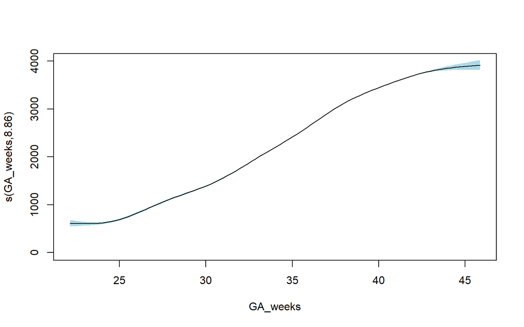

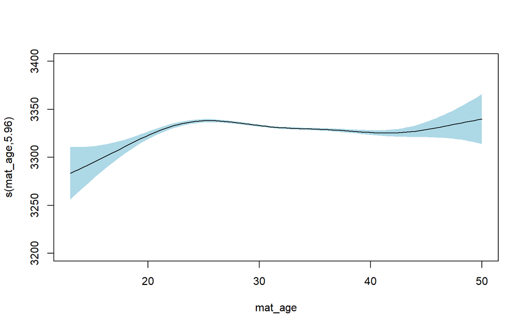

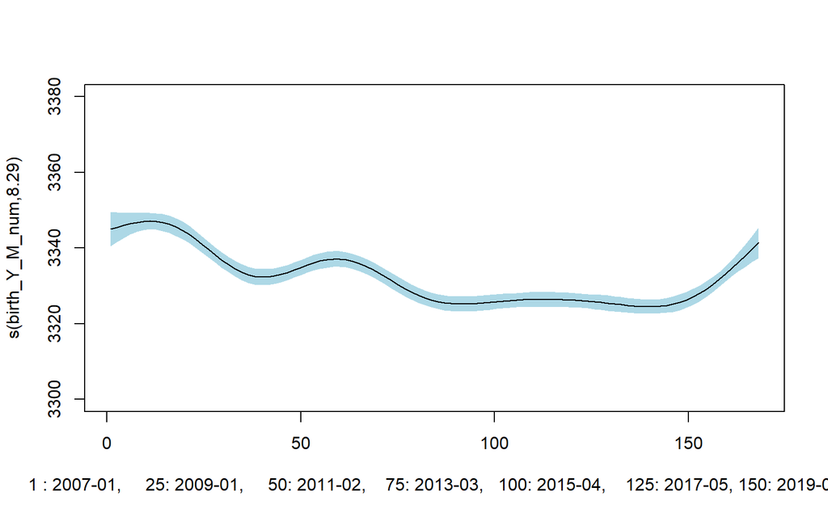

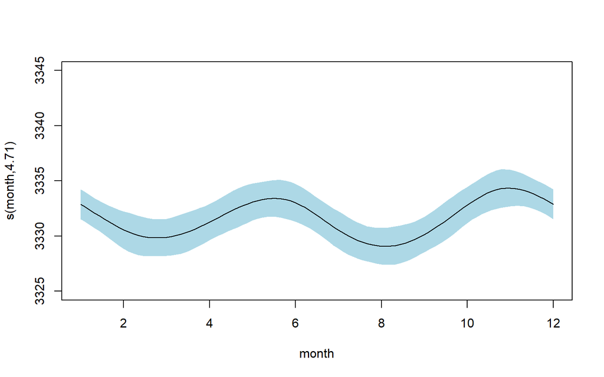

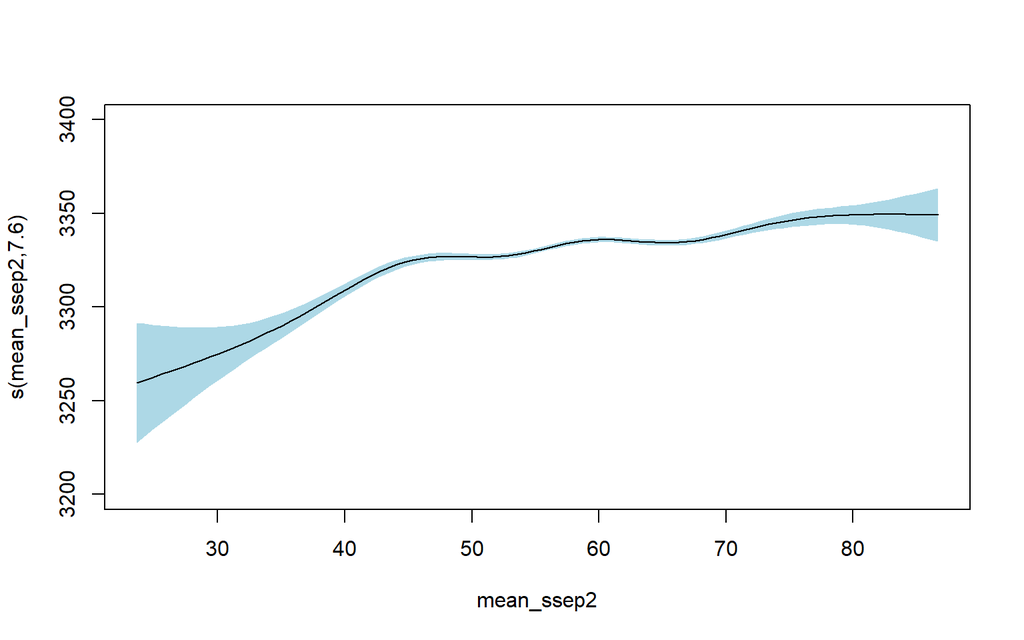

To take into account the fact that we are analysing a huge dataset (n=1,099,368), we calculated Cohen’s d. ([calculation and interpreation of d guide](https://easystats.github.io/effectsize/articles/interpret.html#chen2010big)

)

Cohen’s d formula:

$d=\frac{beta}{SD}$ and $SD=\sqrt{n}*se$

$d=\frac{beta}{\sqrt{n}*se}$

- beta: estimate
- se: standard error
- n: population/observation size
- SD: standard deviation

```
##                                                         beta     lci     uci    d
## (Intercept)                                          3331.71 3330.07 3333.34 3.80
## parity_cat(1,2]                                       127.48  125.84  129.12 0.15
## parity_cat(2,3]                                       173.65  171.14  176.15 0.13
## parity_cat(3,20]                                      199.80  195.46  204.14 0.09
## sex2                                                 -147.04 -148.50 -145.57 0.19
## Urban3                                                  0.66   -0.89    2.21 0.00
## LanguageFrench                                        -48.13  -49.93  -46.33 0.05
## LanguageItalian                                       -63.14  -67.16  -59.12 0.03
## mother_nationality_cat2Africa                          11.03    6.57   15.48 0.00
## mother_nationality_cat2Asia                           -17.93  -21.96  -13.89 0.01
## mother_nationality_cat2Europe                          32.57   30.91   34.24 0.04
## mother_nationality_cat2Northern America                65.02   55.50   74.54 0.01
## mother_nationality_cat2Southern and Central America    47.02   41.54   52.51 0.02
```

Interpretation of m_BW_bam5_2 model :

- Non-smooth terms

Increasing parity increases birthweight compared to first births: from (126g, 129g) at second parity, (171g, 176g) at third parity, to (195g, 204g) for parities over 3.

Being born a female decreases birthweight by (-148g, -146g) compared to males.

Urbanity seems to have no effect on birthweight (it is worth mentioning that it did have an effect as long as mean_ssep variable was not included in the model)

Language region : Compared to babies born in German(+Romansh)-speaking Switzerland, being born in the French-speaking part decreases BW by (-50g,-46g), while being born in the Italian-speaking part decreases BW by (-67g,-59g).

Maternal nationality: compared to babies born from Swiss mothers, babies born from Asian mothers are lighter (-22g, -14g). Babies born from other-nationalities mothers are heavier: (7g, 16g) for Africa, (31g, 34g) for other European countries, (55g, 75g) for Northern America, and (42g-53g) for Southern/Central America. –> What is the biological relevance of these changes? variations of around 50g probably don’t impact much neonatal health.

Interpretation of Cohen’s d parameters: we should not overinterpret these values. Usually it is considered that when d is<0.2, the effect should be considered very small. Here as all our ds are<0.2, it suggests that we may not see all these effects in much smaller datasets.

- Smooth terms

Maternal age: BW increases non-linearly with maternal age: for younger mothers (<25yo) it increases almost linearly from 3280g to 3340g, then declines very slightly until reaching a plateau around 3330g when the mother is 25-40yo. Older women have heavier babies, increasing from 3330g to around 3340g for women 40-50yo (keep in mind we have excluded a few mothers above 50).

Time (month+year combined): globally, BW is decreasing between 2007 and 2019 from 3350 to 3330 which is a minor change, and then increases from 2019 to reach 3350g by the end of 2020. There are some other minor variations throughout the whole time but this doesn’t seem very relevant: only 20g variation.

Seasonal/month: minor sinusoidal seasonal variation between 3330-3340g, with lower birthweight in March and August. These difference dont seem relevant either (10g variation will probably not impact the baby’s health).

Mean ssep: Birthweight increases by increasing ssep, linearly between ssep=25-45 approx (3250-3340g), and then there is some minor birthweight increase for higher ssep, until reaching a BW of around 3360g. Overall, a +100g increase is probably worth mentioning.

## 2008-2010

Because birth_Y_M_num and month variables correlated too much, month variable was not kept in the model. This was done in every “sub” model including only the years 2008-2010 or 2017-2020.

Mean ssep was set as linear variables (when included as a smooth, the graph clearly showed a linear association).

```
##
## Family: gaussian
## Link function: identity
##
## Formula:
## BW ~ s(GA_weeks) + s(mat_age) + s(birth_Y_M_num) + mean_ssep2 +
##     parity_cat + sex + Urban3 + Language + mother_nationality_cat2
##
## Parametric coefficients:
##                                                       Estimate Std. Error t value Pr(>|t|)
## (Intercept)                                          3275.9349     6.4043 511.519  < 2e-16 ***
## mean_ssep2                                              0.8782     0.1044   8.411  < 2e-16 ***
## parity_cat(1,2]                                       122.2189     1.8859  64.807  < 2e-16 ***
## parity_cat(2,3]                                       172.4210     2.8854  59.757  < 2e-16 ***
## parity_cat(3,20]                                      196.6754     4.9252  39.933  < 2e-16 ***
## sex2                                                 -146.2862     1.6810 -87.023  < 2e-16 ***
## Urban3                                                  0.7995     1.7458   0.458  0.64697
## LanguageFrench                                        -46.0119     2.0624 -22.310  < 2e-16 ***
## LanguageItalian                                       -64.9937     4.3480 -14.948  < 2e-16 ***
## mother_nationality_cat2Africa                          41.3021     6.0380   6.840 7.92e-12 ***
## mother_nationality_cat2Asia                           -15.2229     4.9414  -3.081  0.00207 **
## mother_nationality_cat2Europe                          36.4757     1.9398  18.804  < 2e-16 ***
## mother_nationality_cat2Northern America                82.8969    10.6242   7.803 6.09e-15 ***
## mother_nationality_cat2Southern and Central America    60.7497     6.0059  10.115  < 2e-16 ***
## ---
## Signif. codes:  0 '***' 0.001 '**' 0.01 '*' 0.05 '.' 0.1 ' ' 1
##
## Approximate significance of smooth terms:
##                    edf Ref.df        F  p-value
## s(GA_weeks)      8.049  8.697 14885.61  < 2e-16 ***
## s(mat_age)       3.356  4.180     6.88 1.01e-05 ***
## s(birth_Y_M_num) 2.819  3.509    15.17  < 2e-16 ***
## ---
## Signif. codes:  0 '***' 0.001 '**' 0.01 '*' 0.05 '.' 0.1 ' ' 1
##
## R-sq.(adj) =  0.397   Deviance explained = 39.7%
## fREML = 1.6233e+06  Scale est. = 1.5481e+05  n = 219541
```

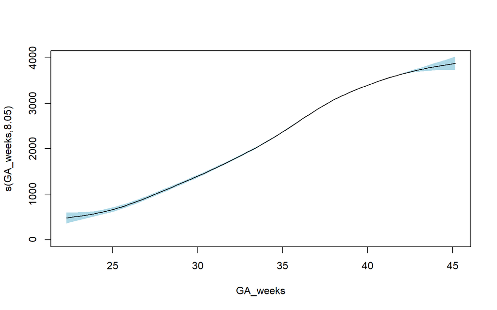

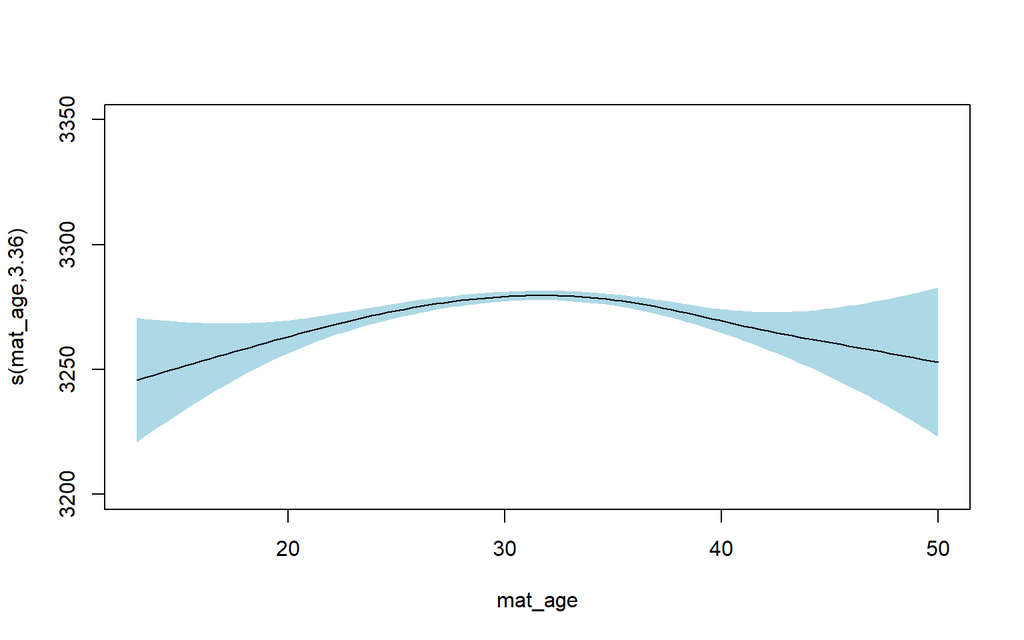

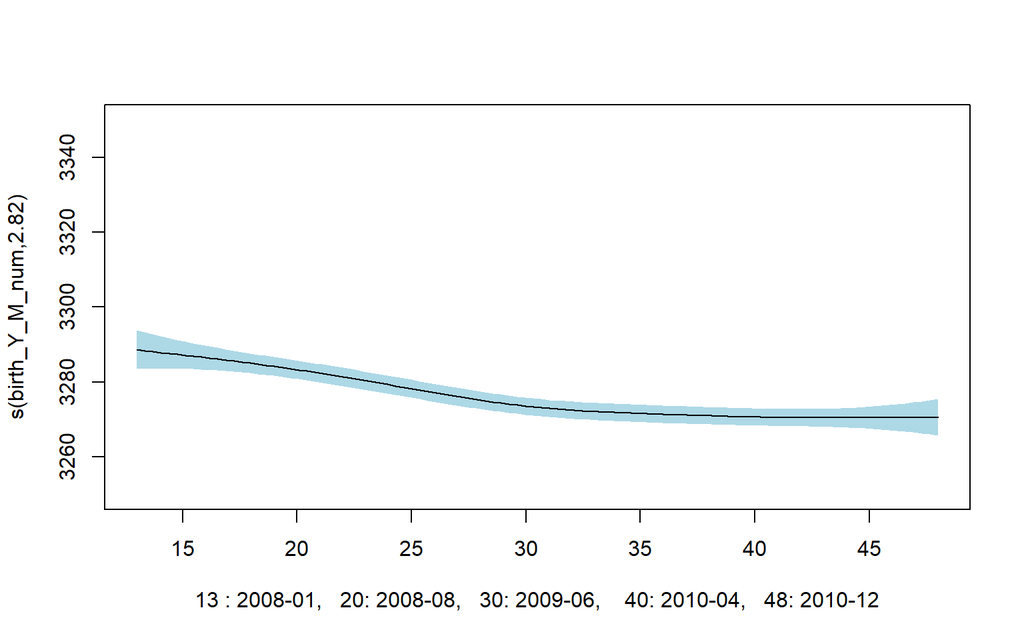

```
##                                                         beta     lci     uci    d
## (Intercept)                                          3275.93 3263.38 3288.49 1.09
## mean_ssep2                                              0.88    0.67    1.08 0.02
## parity_cat(1,2]                                       122.22  118.52  125.92 0.14
## parity_cat(2,3]                                       172.42  166.77  178.08 0.13
## parity_cat(3,20]                                      196.68  187.02  206.33 0.09
## sex2                                                 -146.29 -149.58 -142.99 0.19
## Urban3                                                  0.80   -2.62    4.22 0.00
## LanguageFrench                                        -46.01  -50.06  -41.97 0.05
## LanguageItalian                                       -64.99  -73.52  -56.47 0.03
## mother_nationality_cat2Africa                          41.30   29.47   53.14 0.01
## mother_nationality_cat2Asia                           -15.22  -24.91   -5.54 0.01
## mother_nationality_cat2Europe                          36.48   32.67   40.28 0.04
## mother_nationality_cat2Northern America                82.90   62.07  103.72 0.02
## mother_nationality_cat2Southern and Central America    60.75   48.98   72.52 0.02
```

Comment: there does not seem to be a shift in birthweight/important trend during the 2008-09 economic crisis (times to watch are 2008 Q4 and 2009 Q1: months 21-27).

## 2017-2020

```
##
## Family: gaussian
## Link function: identity
##
## Formula:
## BW ~ s(GA_weeks) + s(mat_age) + s(birth_Y_M_num) + s(mean_ssep2) +
##     parity_cat + sex + Urban3 + Language + mother_nationality_cat2
##
## Parametric coefficients:
##                                                        Estimate Std. Error  t value Pr(>|t|)
## (Intercept)                                          3334.86242    1.51473 2201.623  < 2e-16 ***
## parity_cat(1,2]                                       132.55501    1.50406   88.132  < 2e-16 ***
## parity_cat(2,3]                                       180.86187    2.29397   78.842  < 2e-16 ***
## parity_cat(3,20]                                      202.29423    4.00334   50.531  < 2e-16 ***
## sex2                                                 -144.69240    1.34730 -107.394  < 2e-16 ***
## Urban3                                                 -0.07548    1.42321   -0.053   0.9577
## LanguageFrench                                        -51.24386    1.63396  -31.362  < 2e-16 ***
## LanguageItalian                                       -62.48351    3.94967  -15.820  < 2e-16 ***
## mother_nationality_cat2Africa                          -6.50370    3.76815   -1.726   0.0844 .
## mother_nationality_cat2Asia                           -16.40291    3.54617   -4.626 3.74e-06 ***
## mother_nationality_cat2Europe                          27.21549    1.52235   17.877  < 2e-16 ***
## mother_nationality_cat2Northern America                59.94954    9.02877    6.640 3.15e-11 ***
## mother_nationality_cat2Southern and Central America    38.20471    5.36714    7.118 1.10e-12 ***
## ---
## Signif. codes:  0 '***' 0.001 '**' 0.01 '*' 0.05 '.' 0.1 ' ' 1
##
## Approximate significance of smooth terms:
##                    edf Ref.df         F p-value
## s(GA_weeks)      8.523  8.916 22175.965  <2e-16 ***
## s(mat_age)       5.968  6.885    19.774  <2e-16 ***
## s(birth_Y_M_num) 5.566  6.714     9.925  <2e-16 ***
## s(mean_ssep2)    5.075  6.240    14.884  <2e-16 ***
## ---
## Signif. codes:  0 '***' 0.001 '**' 0.01 '*' 0.05 '.' 0.1 ' ' 1
##
## R-sq.(adj) =  0.399   Deviance explained = 39.9%
## fREML = 2.4535e+06  Scale est. = 1.5059e+05  n = 332448
```

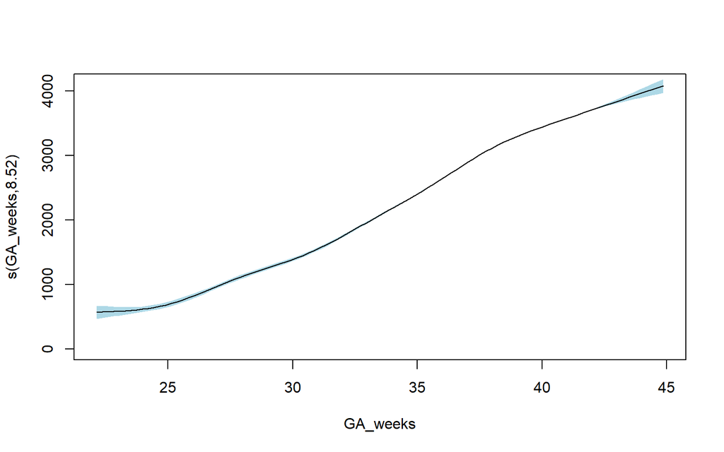

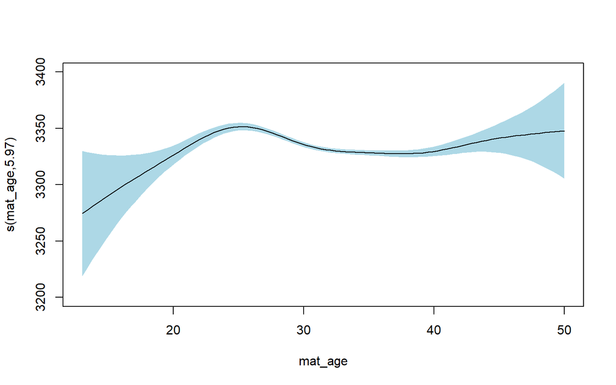

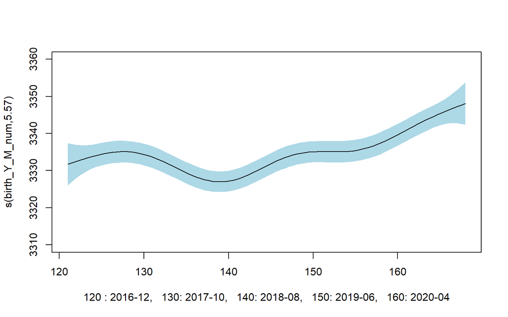

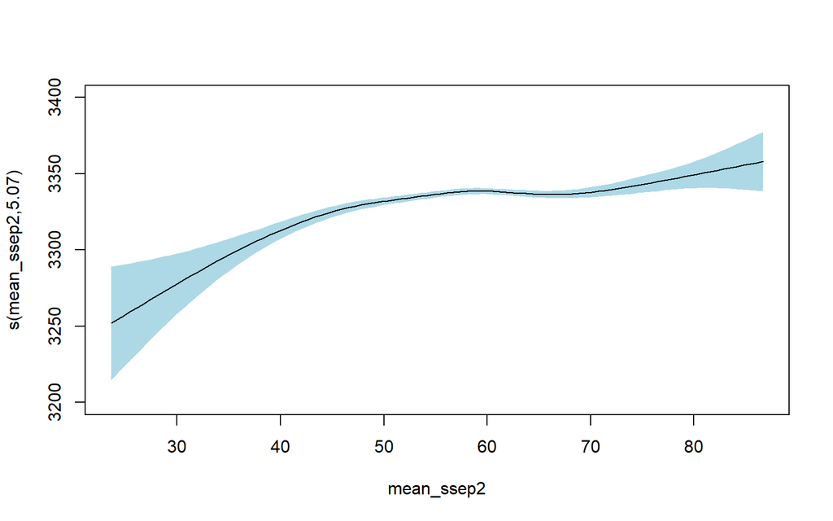

[output not shown]

Comment: birthweight seems to be increasing from 08-2018, with an further marked increase from the end of 2019.

# Stillbirth

## 2007-2020

```
##
## Family: binomial
## Link function: logit
##
## Formula:
## stillbirth ~ s(GA_weeks) + s(mat_age) + s(month, bs = "cc") +
##     birth_Y_M_num + mean_ssep2 + Urban3 + Language + mother_nationality_cat2
##
## Parametric coefficients:
##                                                        Estimate Std. Error z value Pr(>|z|)
## (Intercept)                                          -6.583e+00  1.455e-01 -45.243  < 2e-16 ***
## birth_Y_M_num                                         2.198e-05  3.967e-04   0.055  0.95583
## mean_ssep2                                           -6.279e-03  2.333e-03  -2.691  0.00712 **
## Urban3                                                4.064e-02  3.893e-02   1.044  0.29661
## LanguageFrench                                        7.893e-02  4.407e-02   1.791  0.07328 .
## LanguageItalian                                      -2.127e-02  1.024e-01  -0.208  0.83541
## mother_nationality_cat2Africa                         2.273e-01  9.351e-02   2.431  0.01508 *
## mother_nationality_cat2Asia                          -3.685e-02  1.016e-01  -0.363  0.71689
## mother_nationality_cat2Europe                         3.177e-02  4.252e-02   0.747  0.45504
## mother_nationality_cat2Northern America              -3.485e-01  2.851e-01  -1.222  0.22162
## mother_nationality_cat2Southern and Central America  -9.938e-02  1.351e-01  -0.735  0.46212
## ---
## Signif. codes:  0 '***' 0.001 '**' 0.01 '*' 0.05 '.' 0.1 ' ' 1
##
## Approximate significance of smooth terms:
##               edf Ref.df    Chi.sq p-value
## s(GA_weeks) 7.584  8.134 16732.689  <2e-16 ***
## s(mat_age)  3.218  4.040    12.828  0.0130 *
## s(month)    1.869  8.000     6.857  0.0131 *
## ---
## Signif. codes:  0 '***' 0.001 '**' 0.01 '*' 0.05 '.' 0.1 ' ' 1
##
## R-sq.(adj) =  0.133   Deviance explained = 32.2%
## fREML = 1.5638e+06  Scale est. = 1         n = 1101379
```

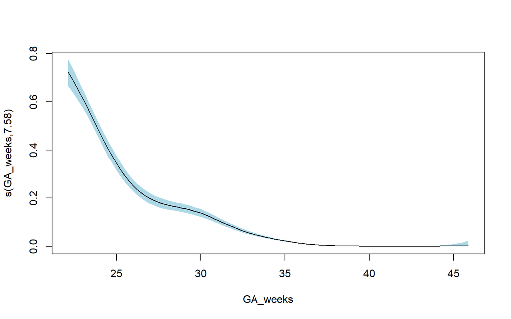

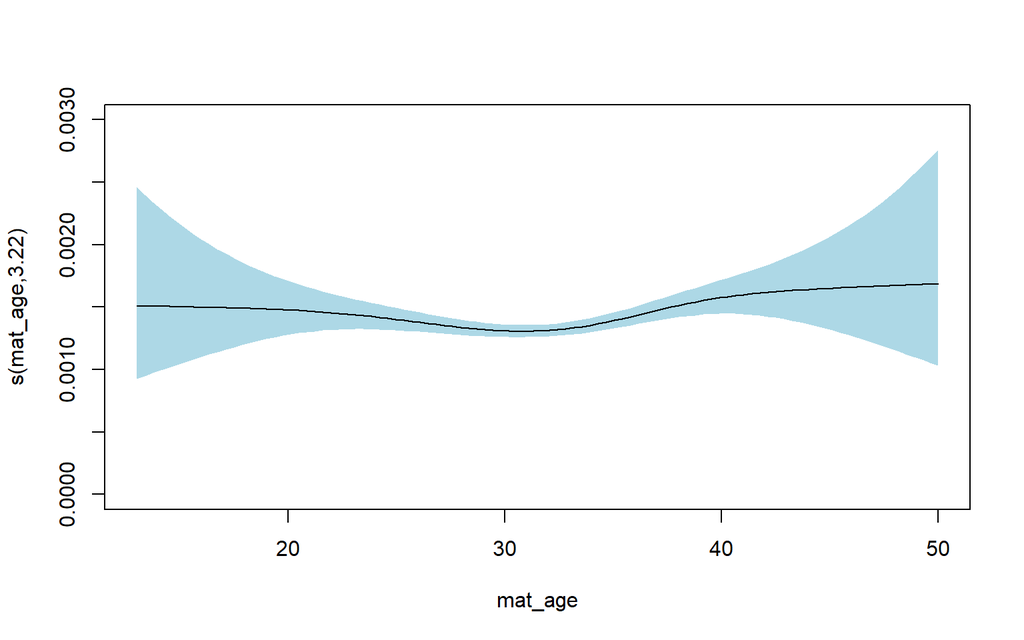

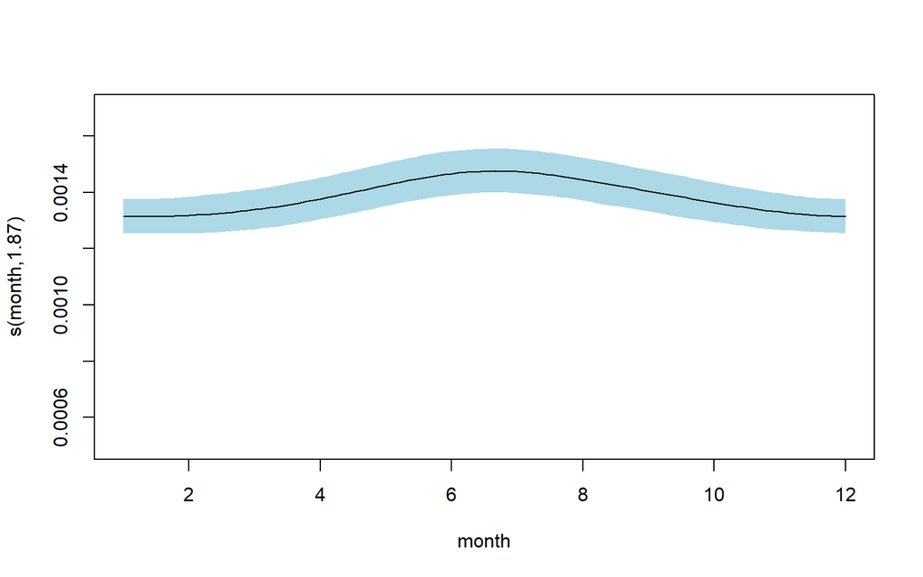

Time variables (birth_Y_M_num) and mean ssep variable were put as linear terms, because the model including them as smoothed terms showed that the relationship between these and stillbirth was linear.

Calculation of Cohen’s d for OR:

$d= \log(OR) * \frac{\sqrt{3}}{\pi}$

$d = \frac{log(OR)}{1.81}$

```
##                                                        OR  lci  uci    d
## (Intercept)                                          0.00 0.00 0.00 3.64
## birth_Y_M_num                                        1.00 1.00 1.00 0.00
## mean_ssep2                                           0.99 0.99 1.00 0.00
## Urban3                                               1.04 0.96 1.12 0.02
## LanguageFrench                                       1.08 0.99 1.18 0.04
## LanguageItalian                                      0.98 0.80 1.20 0.01
## mother_nationality_cat2Africa                        1.26 1.04 1.51 0.13
## mother_nationality_cat2Asia                          0.96 0.79 1.18 0.02
## mother_nationality_cat2Europe                        1.03 0.95 1.12 0.02
## mother_nationality_cat2Northern America              0.71 0.40 1.23 0.19
## mother_nationality_cat2Southern and Central America  0.91 0.69 1.18 0.05
```

Comment:  
- Gestational age has indeed a strong impact on stillbirth risk: the risk declines from 75% to 20% when the baby is born between 22 and 26 weeks. Afterwards, the risk declines to 15% when the baby is born at 31 weeks, and <5% after 35weeks.  
- Maternal age: the risk is a bit reduced for women aged 25-35 years, compared to younger and older mothers, but stays at a very low level (0.15-0.16% compared to 0.13%)  
- Month, seasonality : there seems to be an increased risk of stillbirth during summer >0.14% risk.

## 2017-2020

```
##
## Family: binomial
## Link function: logit
##
## Formula:
## stillbirth ~ s(GA_weeks) + mat_age + birth_Y_M_num + mean_ssep2 +
##     Urban3 + Language + mother_nationality_cat2
##
## Parametric coefficients:
##                                                       Estimate Std. Error z value Pr(>|z|)
## (Intercept)                                          -6.798380   0.471619 -14.415  < 2e-16 ***
## mat_age                                               0.007108   0.006871   1.035 0.300899
## birth_Y_M_num                                        -0.002493   0.002496  -0.999 0.317895
## mean_ssep2                                           -0.001563   0.004273  -0.366 0.714532
## Urban3                                               -0.121493   0.071463  -1.700 0.089115 .
## LanguageFrench                                        0.168595   0.078860   2.138 0.032525 *
## LanguageItalian                                      -0.244907   0.230069  -1.064 0.287105
## mother_nationality_cat2Africa                         0.552555   0.149223   3.703 0.000213 ***
## mother_nationality_cat2Asia                           0.191980   0.167095   1.149 0.250587
## mother_nationality_cat2Europe                         0.022874   0.078370   0.292 0.770388
## mother_nationality_cat2Northern America               0.274915   0.439797   0.625 0.531909
## mother_nationality_cat2Southern and Central America   0.045826   0.242218   0.189 0.849942
## ---
## Signif. codes:  0 '***' 0.001 '**' 0.01 '*' 0.05 '.' 0.1 ' ' 1
##
## Approximate significance of smooth terms:
##               edf Ref.df Chi.sq p-value
## s(GA_weeks) 7.398  8.091   4939  <2e-16 ***
## ---
## Signif. codes:  0 '***' 0.001 '**' 0.01 '*' 0.05 '.' 0.1 ' ' 1
##
## R-sq.(adj) =  0.127   Deviance explained = 33.1%
## fREML = 4.7405e+05  Scale est. = 1         n = 333417
```

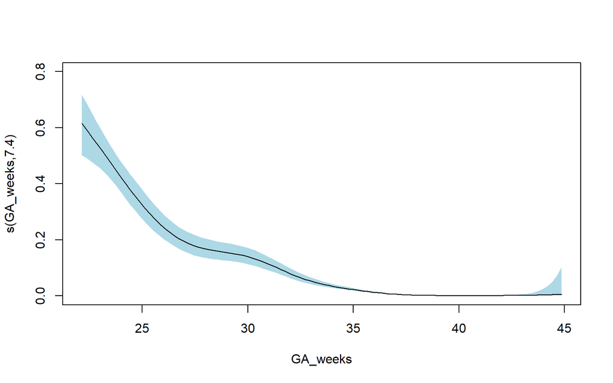

```
##                                                        OR  lci  uci    d
## (Intercept)                                          0.00 0.00 0.00 3.76
## mat_age                                              1.01 0.99 1.02 0.00
## birth_Y_M_num                                        1.00 0.99 1.00 0.00
## mean_ssep2                                           1.00 0.99 1.01 0.00
## Urban3                                               0.89 0.77 1.02 0.07
## LanguageFrench                                       1.18 1.01 1.38 0.09
## LanguageItalian                                      0.78 0.50 1.23 0.14
## mother_nationality_cat2Africa                        1.74 1.30 2.33 0.31
## mother_nationality_cat2Asia                          1.21 0.87 1.68 0.11
## mother_nationality_cat2Europe                        1.02 0.88 1.19 0.01
## mother_nationality_cat2Northern America              1.32 0.56 3.12 0.15
## mother_nationality_cat2Southern and Central America  1.05 0.65 1.68 0.03
```

Why we chose this model: Maternal age had edf values very close to one: we put it as a linear term instead of smoothed variable. As for the previous model (including all timing 2007-2020), we kept time (birth_Y_M_num) and mean_ssep2 variables as linear terms.

- Time: apparently no effect
- French speaking Switzerland: the increased risk of stillbirth persists.
- Babies born from African mothers: the risk is furthermore increased compared to the whole timeline: OR 1.3-2.33